# Lab 3: Exploring Happiness

Due: Thursday 10/03/2019 by 10 pm

Cameron Stocker and Tyler Kruzan

10/3/2019

Owner’s username: tkruzan Partner’s username: CameronStocker repo name: ds202_lab3

## Background

| Variable | Description |
| --- | --- |
| Year | Year for this respondent |
| Age | Age of respondent |
| Sex | Sex of respondent |
| Happy | General Happiness |
| Marital | Marital Status |
| Degree | Respondent’s highest degree |
| Finrela | Opinion of family income |
| Health | Condition of health |
| Wtssall | Weight of variables |
| Partyid | Political party affiliation |
| Polviews | Think of self as liberal or conservative |

Now it’s important to understand what each column stands for. You can find a codebook with explanations for each of the variables at https://gssdataexplorer.norc.org/

## Data Cleaning

Initial exploration revealed that some data processing was needed before we could proceed with further visualization. All missing values were encoded with ‘NA’ as follows:

```r
happy <- readRDS("HAPPY.rds")
names(happy) = tolower(names(happy))
head(happy)
```

```
##           happy year age    sex       marital         degree       finrela
## 1 NOT TOO HAPPY 1972  23 FEMALE NEVER MARRIED       BACHELOR       AVERAGE
## 2 NOT TOO HAPPY 1972  70   MALE       MARRIED LT HIGH SCHOOL ABOVE AVERAGE
## 3  PRETTY HAPPY 1972  48 FEMALE       MARRIED    HIGH SCHOOL       AVERAGE
## 4 NOT TOO HAPPY 1972  27 FEMALE       MARRIED       BACHELOR       AVERAGE
## 5  PRETTY HAPPY 1972  61 FEMALE       MARRIED    HIGH SCHOOL ABOVE AVERAGE
## 6  PRETTY HAPPY 1972  26   MALE NEVER MARRIED    HIGH SCHOOL ABOVE AVERAGE
##      health wtssall          partyid polviews
## 1      GOOD  0.4446     IND,NEAR DEM      IAP
## 2      FAIR  0.8893 NOT STR DEMOCRAT      IAP
## 3 EXCELLENT  0.8893      INDEPENDENT      IAP
## 4      GOOD  0.8893 NOT STR DEMOCRAT      IAP
## 5      GOOD  0.8893  STRONG DEMOCRAT      IAP
## 6      GOOD  0.4446     IND,NEAR DEM      IAP
```

```r
happy[happy == "NA"] = NA
happy[happy == "IAP"] = NA
happy[happy == "DK"] = NA
length(which(is.na(happy)))
```

```
## [1] 36391
```

```r
length(which(is.na(happy$happy)))
```

```
## [1] 4756
```

```r
length(which(is.na(happy$year)))
```

```
## [1] 0
```

```r
length(which(is.na(happy$age)))
```

```
## [1] 221
```

```r
length(which(is.na(happy$sex)))
```

```
## [1] 0
```

```r
length(which(is.na(happy$marital)))
```

```
## [1] 25
```

```r
length(which(is.na(happy$degree)))
```

```
## [1] 173
```

```r
length(which(is.na(happy$finrela)))
```

```
## [1] 5001
```

```r
length(which(is.na(happy$health)))
```

```
## [1] 16445
```

```r
length(which(is.na(happy$wtssall)))
```

```
## [1] 0
```

```r
length(which(is.na(happy$partyid)))
```

```
## [1] 385
```

```r
length(which(is.na(happy$polviews)))
```

```
## [1] 9385
```

Variables were also cast into the correct type in order to ease data visualization. This was done by:

```r
happy$age[happy$age == "89 OR OLDER"] = "89"
happy$age = as.numeric(happy$age)
happy$happy = factor(happy$happy)
happy$sex = factor(happy$sex)
happy$marital = factor(happy$marital)
happy$degree = factor(happy$degree)
happy$finrela = factor(happy$finrela)
happy$health = factor(happy$health)
happy$partyid = factor(happy$partyid)
happy$polviews = factor(happy$polviews)
```

Factors were also organized into meaningful order as follows:

```r
happy$degree = factor(happy$degree, levels(happy$degree)[c(5,3,4,1,2)])
happy$marital = reorder(happy$marital, happy$age, FUN = mean)
```

## Data Exploration

Two variables of interest are happiness and age. Their distributions are as follow:

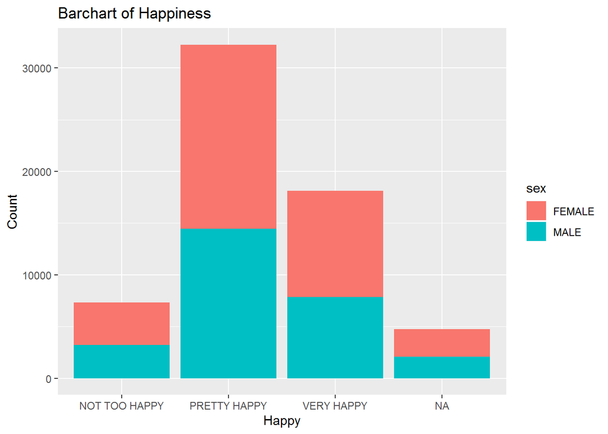

```r
library(ggplot2)
ggplot(happy, aes(happy, fill = sex)) + geom_bar() + labs(title = "Barchart of Happiness", x = "Happy", y = "Count")
```

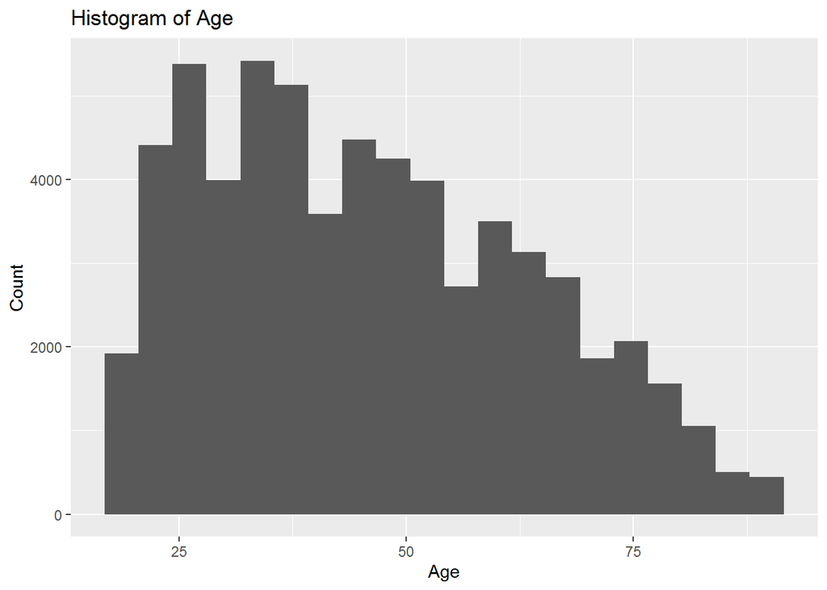

```r
ggplot(happy, aes(age)) + geom_histogram(bins = 20) + labs(title = "Histogram of Age", x = "Age", y = "Count")
```

The distribution for happiness has a lot more people who are pretty happy or very happy compared to not too happy, suggesting that most people are fairly happy with their lives. There is an approximately even distribution of sex within each level of happiness, suggesting neither sex is more happy than the other.

The distibution for age is a skew right. Suggesting that more people are of the age 20-40 than those in the years older than that.

Here we look at the relationship between happiness and age.

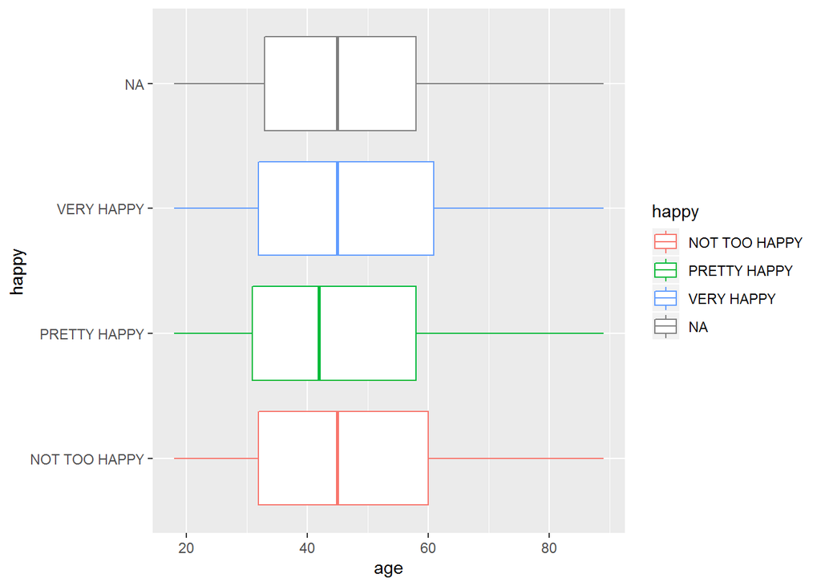

```r
ggplot(happy, aes(happy, age, color = happy)) + geom_boxplot() + coord_flip()
```

Here you can see a boxplot comparing levels of happiness relative to their age. Although we can’t come to any concrete conclusions, it does appear that those who are very happy and not too happy might be slightly older than those who are pretty happy. This could be due to the fact those that are younger are still figuring out life and don’t really know either way.

Next we look at the relationship between happiness and degree.

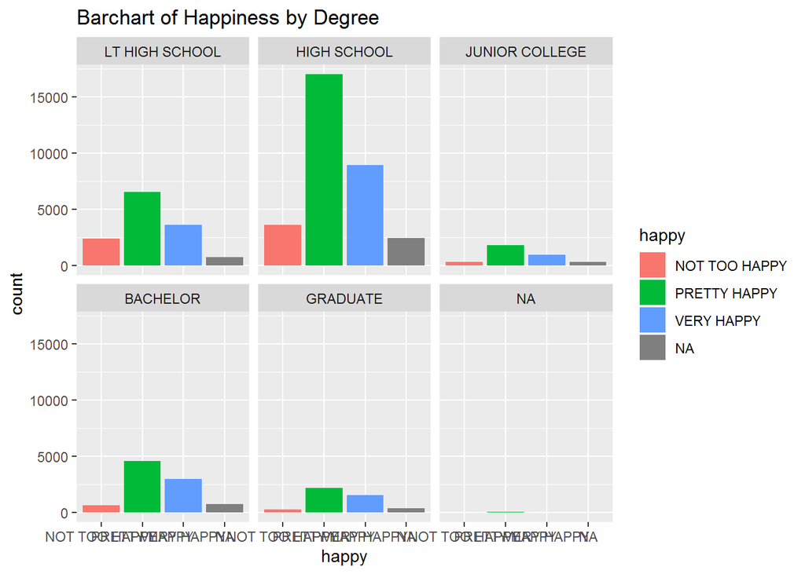

```r
ggplot(happy, aes(happy, fill = happy)) + facet_wrap(~degree) + geom_bar() + labs(title = "Barchart of Happiness by Degree")
```

Here you can see that most people are pretty happy, regardless of their degree. The distribution between not too happy, pretty happy, and very happy look very similar in each graph. This tells us that someone’s level of education doesn’t necessarily correlate to their level of happiness.

Lastly we looked at happiness relative to the year and weight of the variables.

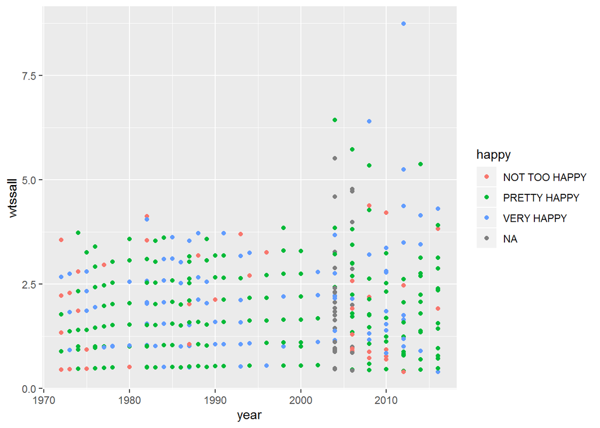

```r
ggplot(happy, aes(year, wtssall, color = happy)) + geom_point()
```

There were not too many signifant findings in this graph. The only thing that stands out would be that we discovered that most of the NA observations for happiness came from around the year 2004.

Overall, we were unable to find any variables that we can confidently say correlated with happiness.